# Tidyverse Create project – Using across() function

Esteban Aramayo

2021-04-25

### Project summary

In this project I will show how to compute summary statistics across multiple columns in R using the **dplyr’s across()** function. In **dplyr’s release 1.0.4 (2021-02-02)** the **across() function** makes **summarise(across())** and **mutate(across())** perform much faster than ever.

### Why use the across() function

In certain situations one needs to calculate summary statistics like mean/median/std or some other function on multiple columns. Usually we calculate summary statistics by manually doing it for each variable (column) one by one. In a dataset with many columns, it can be very tedious to calculate the summary statistics on such columns, especially if we want to combine the calculated statistics with the **summarise()** and **mutate()** functions.

The dplyr’s across() function allows us to apply the same statistical function to multiple variables at the same time and it allows us to combine them with the **summarise()** and **mutate()** functions.

```r
library(tidyverse)

if (!require("DT")) install.packages('DT')
library(DT)
```

### Load & view the dataset

For this project we will use the “Nifty 500 fundamental statistics” dataset, which includes Top 500 companies listed on the National Stock Exchange (NSE) in India.

The original dataset can be downloaded from:

https://www.kaggle.com/dhimananubhav/nifty-500-fundamental-statistics?select=nifty_500_stats.csv

```r
url <- 'https://raw.githubusercontent.com/esteban-data-enthusiast/DATA607/main/datasets/nifty_500_stats.csv'

my_col_types <- cols(
   index            = col_integer(),
   company          = col_character(),
   industry         = col_character(),
   symbol           = col_character(),
   market_cap       = col_double(),
   current_value    = col_double(),
   high_52week      = col_double(),
   low_52week       = col_double(),
   book_value       = col_double(),
   price_earnings   = col_double(),
   dividend_yield   = col_double(),
   roce             = col_double(),
   roe              = col_double(),
   sales_growth_3yr = col_double()
 )

ds <- read_delim(file = url, delim = ";",
                 col_names = TRUE, col_types = my_col_types)
```

Let’s take a peak at our dataset

| index | company | industry | symbol | category | market_cap | current_value | high_52week | low_52week | book_value | price_earnings | dividend_yield | roce | roe | sales_growth_3yr |
| --- | --- | --- | --- | --- | --- | --- | --- | --- | --- | --- | --- | --- | --- | --- |
| 0 | Adani Ports and Special Economic Zone Ltd. | SERVICES | ADANIPORTS | Nifty 50 | 69087 | 333.6 | 451.55 | 293.95 | 90.36 | 28.32 | 0.6 | 14.96 | 14.82 | 18.67 |
| 1 | Asian Paints Ltd. | CONSUMER GOODS | ASIANPAINT | Nifty 50 | 119612 | 1247 | 1488.6 | 1082 | 84.29 | 58.5 | 0.7 | 38.71 | 25.47 | 8.44 |
| 2 | Axis Bank Ltd. | FINANCIAL SERVICES | AXISBANK | Nifty 50 | 156906 | 610.65 | 676.9 | 477.5 | 246.92 | 5525 | 0 | 4.4 | 0.11 | 8.87 |
| 3 | Bajaj Auto Ltd. | AUTOMOBILE | BAJAJ-AUTO | Nifty 50 | 76907 | 2658 | 3472.6 | 2425 | 654.55 | 17.89 | 2.26 | 31.96 | 22.63 | 5.2 |
| 4 | Bajaj Finance Ltd. | FINANCIAL SERVICES | BAJFINANCE | Nifty 50 | 137747 | 2383 | 2995.1 | 1514.4 | 300.47 | 42.21 | 0.17 | 12.74 | 20.27 | 35.08 |
| 5 | Bajaj Finserv Ltd. | FINANCIAL SERVICES | BAJAJFINSV | Nifty 50 | 87927 | 5525 | 7200 | 4444 | 197.95 | 275.44 | 0.03 | 5.91 | 5.01 | 6.09 |
| 6 | Bharat Petroleum Corporation Ltd. | ENERGY | BPCL | Nifty 50 | 65587 | 302.35 | 543.6 | 239 | 164.35 | 7.87 | 6.3 | 21.76 | 24.61 | -0.25 |
| 7 | Bharti Airtel Ltd. | TELECOM | BHARTIARTL | Nifty 50 | 120741 | 302.05 | 565 | 277 | 251.22 |  | 1.77 | 3.58 | 0.73 | -1.11 |
| 8 | Bharti Infratel Ltd. | TELECOM | INFRATEL | Nifty 50 | 48515 | 262.3 | 443.3 | 241.8 | 89.2 | 18.74 | 5.34 | 19.78 | 14.7 | 7.09 |
| 9 | Cipla Ltd. | PHARMA | CIPLA | Nifty 50 | 48887 | 607.1 | 678 | 508.1 | 175.27 | 29.46 | 0.49 | 13.92 | 10.82 | 3.98 |

[output cut: 490 more lines]

### Let’s use the across() function

Let’s calculate the mean per industry for all numeric fields at once.

```r
# Use the .names argument to control the output names
num_vars_means <- ds %>%
  select(industry:sales_growth_3yr ) %>%
  group_by(industry) %>%
  summarise(across(where(is.numeric), mean, .names = "mean_{col}"))
```

Let’s show the calculated means per numeric field per industry.

| industry | mean_market_cap | mean_current_value | mean_high_52week | mean_low_52week | mean_book_value | mean_price_earnings | mean_dividend_yield | mean_roce | mean_roe | mean_sales_growth_3yr |
| --- | --- | --- | --- | --- | --- | --- | --- | --- | --- | --- |
| AUTOMOBILE | 36750.92 | 5577.16 | 7127.474 | 4952.1576 | 1383.286 | 29.3072 | 0.9016 | 22.762 | 17.2016 |  |
| CEMENT &amp; CEMENT PRODUCTS | 20778.1875 | 1534.58125 | 2131.984375 | 1357.6125 | 410.855625 |  | 0.82875 | 11.510625 | 7.379375 | 6.868125 |
| CHEMICALS | 8709 | 840.966666666667 | 1079.61277777778 | 656.222222222222 | 226.055555555556 | 38.2544444444444 | 1.055 | 18.1583333333333 | 15.625 | 9.70722222222222 |
| CONSTRUCTION | 11933.7806060606 | 322.427272727273 | 527.41696969697 | 278.88303030303 | 116.549090909091 |  | 0.851212121212121 | 14.5233333333333 | 11.0530303030303 | 14.2387878787879 |
| CONSUMER GOODS | 26268.2465753425 | 1101.82602739726 | 1469.37287671233 | 883.431506849315 | 124.725342465753 |  | 0.751095890410959 | 26.1145205479452 | 18.8976712328767 |  |
| ENERGY | 53061.1212121212 | 248.410606060606 | 355.683333333333 | 205.024545454545 | 141.25696969697 |  | 3.04393939393939 | 18.1224242424242 | 13.8581818181818 | 7.15151515151515 |
| FERTILISERS &amp; PESTICIDES | 8315.36363636364 | 832.104545454545 | 1078.11363636364 | 587.631818181818 | 168.626363636364 | 25.7754545454545 | 1.05181818181818 | 15.3309090909091 | 14.1772727272727 | 2.21454545454545 |
| FINANCIAL SERVICES | 36059.4015384615 | 499.333516483516 |  |  | 180.221648351648 |  | 1.23802197802198 | 11.1468131868132 | 5.8156043956044 |  |
| HEALTHCARE SERVICES | 6853.83333333333 | 509.9 | 627.375 | 443.15 | 103.683333333333 |  | 0.46 | 14.9 | 9.23333333333333 |  |
| INDUSTRIAL MANUFACTURING | 9724.57777777778 | 1273.77333333333 | 1657.83888888889 | 995.951111111111 | 250.637333333333 |  | 0.990666666666667 | 19.2826666666667 | 8.57066666666667 |  |

[output cut: 8 more lines]

### Conclusions

The dplyr’s across() function is a very powerful one, which allows to calculate statistical functions on multiple columns at once. As a bonus, it also allows us to automatically name the calculated fields without having to do it manually.

Also, instead of storing the calculated fields in a separate dataframe, we could also use the mutate() function to append those new fields to the original dataframe as new columns.

## Extending the Vignette

*Author: Claire Meyer*

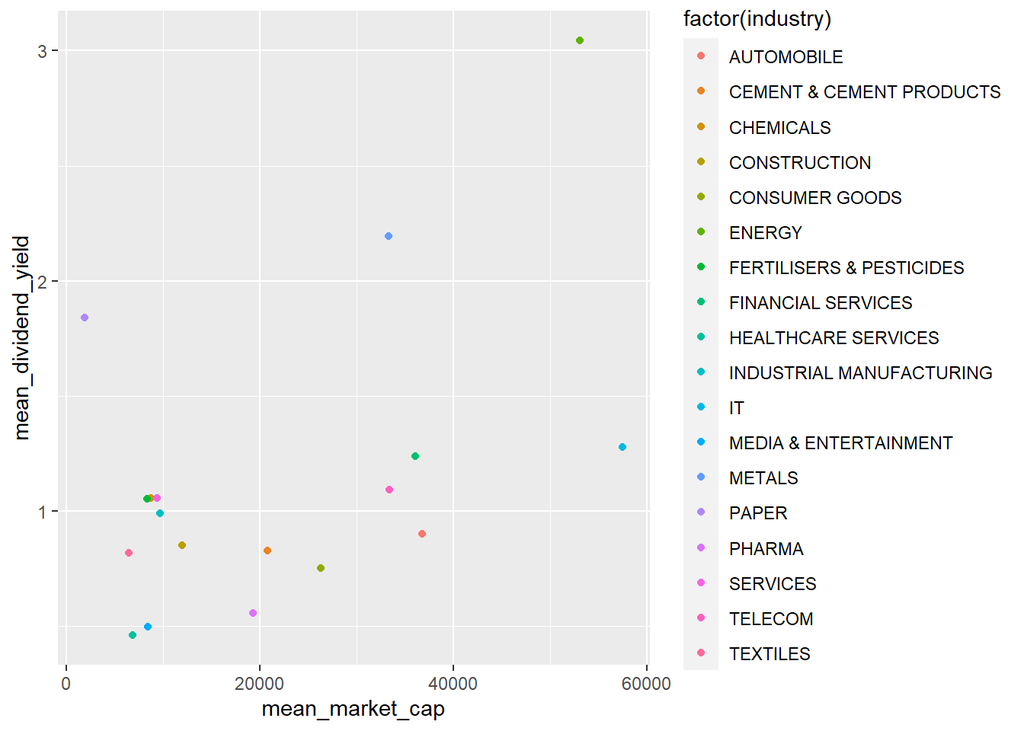

```r
num_vars_means %>%
   ggplot(aes(x=mean_market_cap,y=mean_dividend_yield)) +
          geom_point(aes(color=factor(industry)))
```

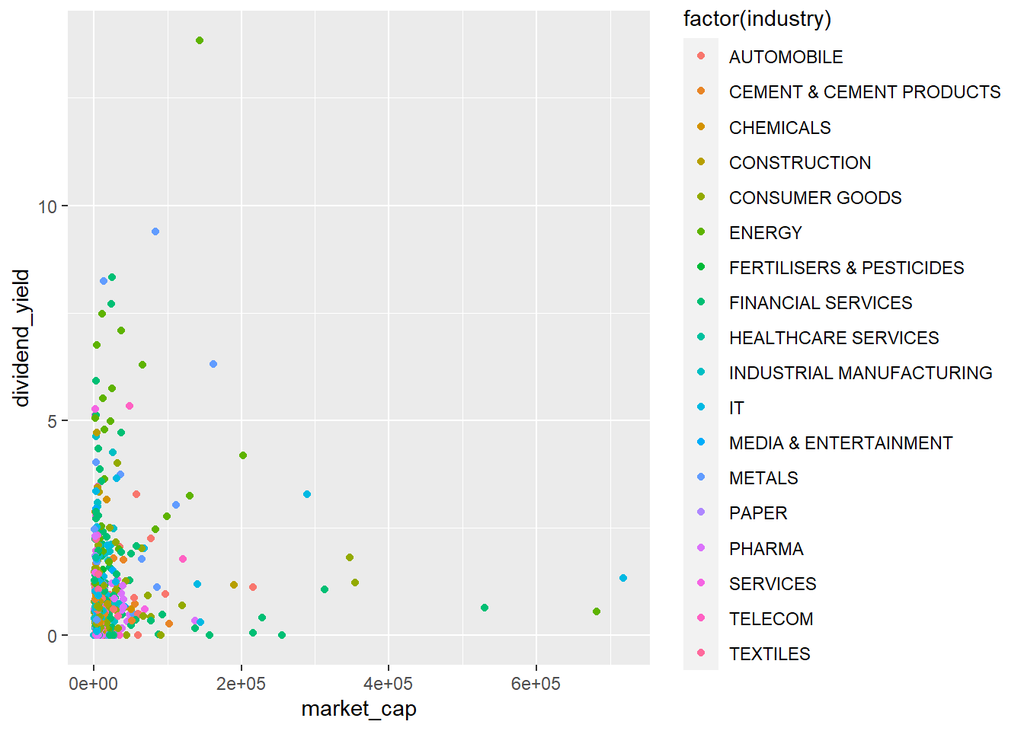

```r
ds %>%
   ggplot(aes(x=market_cap,y=dividend_yield)) +
          geom_point(aes(color=factor(industry)))
```

We can also play with a geom_label or geom_text plot, to more easily see which industry mean falls where, though this has it’s challenges (label sizing, namely):

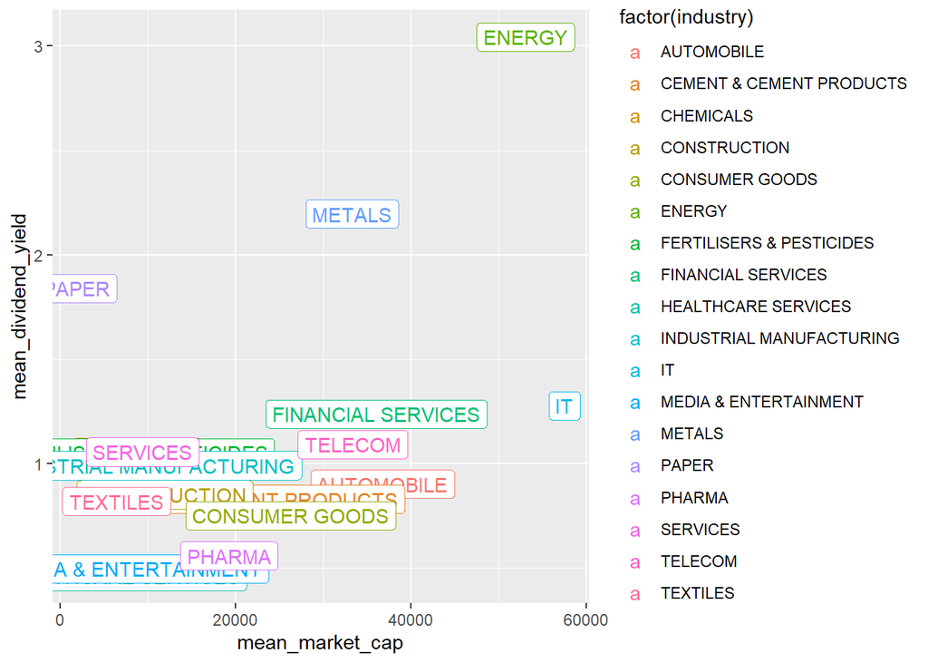

```r
num_vars_means %>%
   ggplot(aes(x=mean_market_cap,y=mean_dividend_yield)) +
          geom_label(aes(color=factor(industry),label=industry))
```

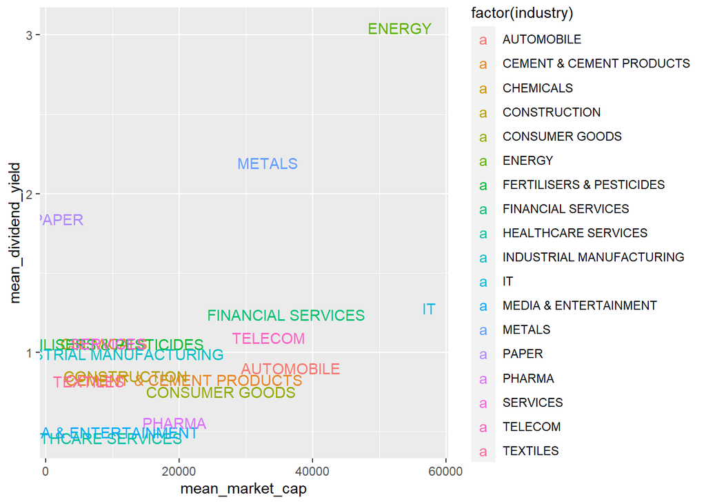

```r
num_vars_means %>%
   ggplot(aes(x=mean_market_cap,y=mean_dividend_yield)) +
          geom_text(aes(color=factor(industry),label=industry))
```

We can also look at a histogram of market caps in all the original data, again with a view by industry, though at this number of industries it’s a bit hard to discern:

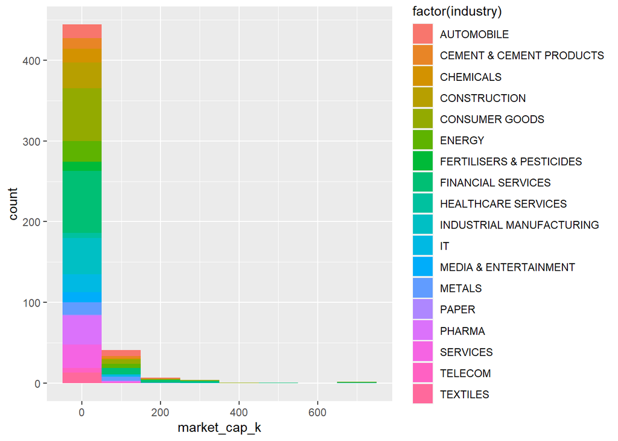

```r
ds %>%
   mutate(market_cap_k = market_cap/1000) %>%
   ggplot(aes(x=market_cap_k,fill=factor(industry))) +
   geom_histogram(binwidth=100)
```

Finally, if we want to more visually size each industry, we can do so with geom_count().

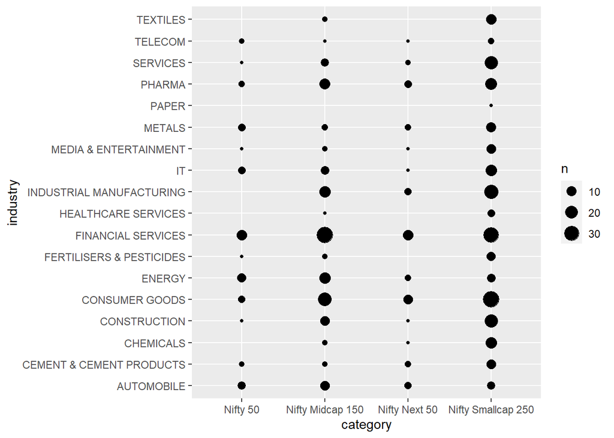

```r
ds %>%
   ggplot(aes(x=category,y=industry)) + geom_count()
```